# Boston Project

## Introduction

This project analyses the Boston data set. It concerns the median value of housing in the Boston Standard Metropolitan Statistical Area in 1970 and related variables such as socio-economic conditions, environmental conditions, educational facilities and some other similar factors.

There are 506 observations in the data for 14 variables including the natural logarithm of the per capita crime rate by town in Boston. There are 12 numerical variables in our dataset and 1 categorical variable. The aim of this project is to build and interpret linear regression models for predicting the natural logarithm of the per capita crime rate (lcrim) in terms of the other variables.

## Contents

1. Variable Description
2. Data Exploration
3. Best Model Identification:
- Best Subset Selection
- Forward Selection
- Backward Elimination
- Stepwise Selection
- Ridge Regression
- The LASSO
- Elastic Net Regression
4. Comparing Model Performance

## Variable Description

The 14 variables included within the data are:

- LCRIM - Natural logarithm of the per capita crime rate by town.
- ZN - Proportion of residential land zoned for lots over 25,000 sq.ft.
- INDUS - Proportion of non-retail business acres per town
- CHAS - Charles River dummy variable (= 1 if tract bounds river; 0 otherwise)
- NOX - Nitrogen oxides concentration (parts per 10 million)
- RM - Average number of rooms per dwelling
- AGE - Proportion of owner-occupied units built prior to 1940
- DISF - A numerical vector representing an ordered categorical variable with four levels depending on the weighted mean of the distances to five Boston employment centres (=1 if distance < 2.5, =2 if 2.5 <= distance < 5, =3 if 5 <= distance < 7.5, =4 if distance >= 7.5).
- RAD - Index of accessibility to radial highways
- TAX - Full-value property-tax rate per $10,000
- PTRATIO - Pupil-teacher ratio by town
- B - 1000(Bk - 0.63)^2 where Bk is the proportion of blacks by town
- LSTAT - % lower status of the population
- MEDV - Median value of owner-occupied homes in $1000’s

## Data Exploration

Firstly, the summary statistics and distribution of the observations in each variable were identified. There are no missing values in the data. However the summary statistics suggest that there might be outliers in some of the variables.

#### Pairs Plot of Numeric Variables

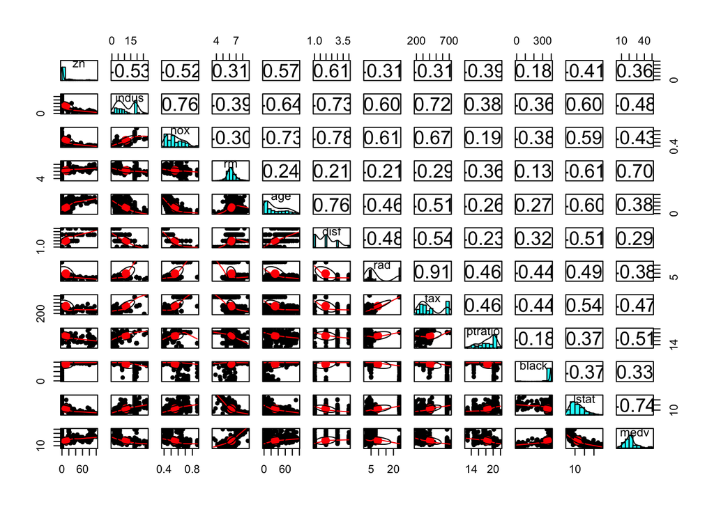

```r
pairs.panels(Boston[c(-1,-4)], cex=2)
```

#### Boxplot

In order to identify variation in the variables, a boxplot was used. This showed that there are outliers in the variables ‘lstat’, ‘medv’, ‘zn’ and most distinctly, ‘black’. Highest variability is observed in the full-value property tax rates.

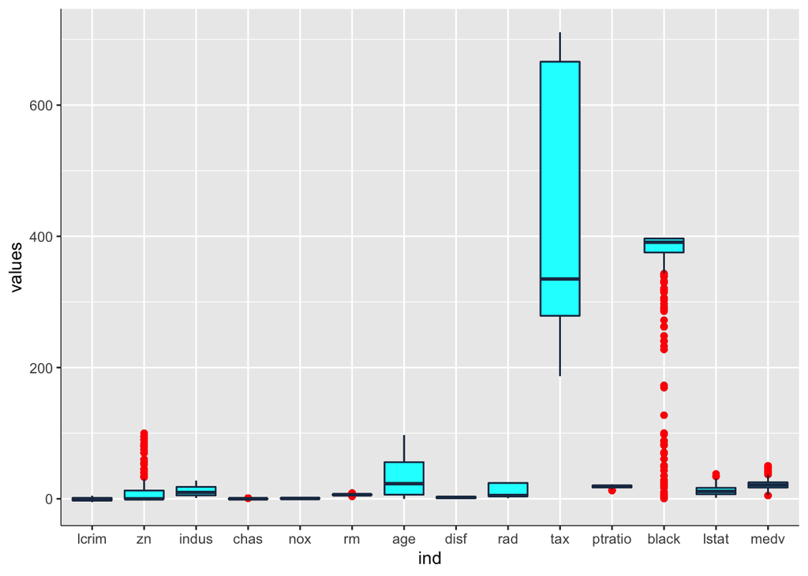

#### Correlation Matrix

Numerous predictors (indus, nox, age, disf, rad, tax & lstat) have high correlation with the outcome variable.

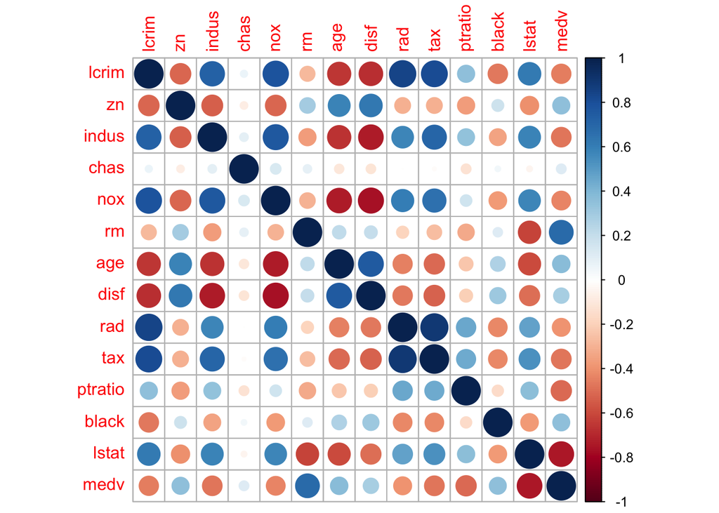

Linear regression was performed on the dataset. The variable of our interest here is ‘lcrim’. Our main objective is to predict the value of ‘lcrim’ based on other independent variables present in the dataset.

## Best Model Identification

### Subset Selection

```
##
## Call:
## lm(formula = lcrim ~ ., data = train)
##
## Residuals:
##      Min       1Q   Median       3Q      Max
## -2.54915 -0.55513 -0.06036  0.49721  2.60695
##
## Coefficients:
##               Estimate Std. Error t value Pr(>|t|)
## (Intercept) -3.1218656  1.0495350  -2.975  0.00312 **
## zn          -0.0107115  0.0023089  -4.639 4.78e-06 ***
## indus        0.0223041  0.0112031   1.991  0.04719 *
## chas         0.0626937  0.1604405   0.391  0.69619
## nox          3.4559851  0.6981139   4.950 1.10e-06 ***
## rm          -0.0011572  0.0846629  -0.014  0.98910
## age         -0.0022639  0.0024894  -0.909  0.36369
## disf        -0.1401838  0.0817411  -1.715  0.08714 .
## rad          0.1478734  0.0113598  13.017  < 2e-16 ***
## tax         -0.0003450  0.0006590  -0.524  0.60089
## ptratio     -0.0538440  0.0250084  -2.153  0.03193 *
## black       -0.0011183  0.0004898  -2.283  0.02296 *
## lstat        0.0414741  0.0102376   4.051 6.15e-05 ***
## medv         0.0112956  0.0082704   1.366  0.17279
## ---
## Signif. codes:  0 '***' 0.001 '**' 0.01 '*' 0.05 '.' 0.1 ' ' 1
##
## Residual standard error: 0.7721 on 390 degrees of freedom
## Multiple R-squared:  0.8746, Adjusted R-squared:  0.8704
## F-statistic: 209.2 on 13 and 390 DF,  p-value: < 2.2e-16
```

From the summary statistics of the model we observe that rad, nox and zn have the most significance as they have the lowest p values ((Pr(>|t|)<0.001). The coefficient estimate of zn variable is negative indicating that the value of response variable lcrim decreases as the percentage of people with residential land zoned for lots over 25,000sq ft increases.

We will now apply different techniques of variable selection to decide the best fit model.

### Best Subset Selection

We wish to predict the crime rate by town based on the available predictors by applying the best subset selection approach. We decide on the number of variables that are required in the model using BIC, r squared and adjusted r squared.

```
##    (Intercept) zn indus chas nox rm age disf rad tax ptratio black lstat medv
## 1            1  0     0    0   0  0   0    0   1   0       0     0     0    0
## 2            1  0     0    0   1  0   0    0   1   0       0     0     0    0
## 3            1  1     0    0   1  0   0    0   1   0       0     0     0    0
## 4            1  1     0    0   1  0   0    0   1   0       0     0     1    0
## 5            1  1     0    0   1  0   0    1   1   0       0     0     1    0
## 6            1  1     0    0   1  0   0    1   1   0       1     0     1    0
## 7            1  1     0    0   1  0   0    1   1   0       1     1     1    0
## 8            1  1     1    0   1  0   0    1   1   0       1     1     1    0
## 9            1  1     1    0   1  0   0    1   1   0       1     1     1    1
## 10           1  1     1    0   1  0   1    1   1   0       1     1     1    1
## 11           1  1     1    0   1  0   1    1   1   1       1     1     1    1
## 12           1  1     1    1   1  0   1    1   1   1       1     1     1    1
## 13           1  1     1    1   1  1   1    1   1   1       1     1     1    1
##          bic    adj.r2
## 1  -500.2572 0.7178978
## 2  -717.6186 0.8373043
## 3  -756.0275 0.8538765
## 4  -775.6994 0.8625297
## 5  -782.3458 0.8664320
## 6  -784.4538 0.8687566
## 7  -782.4812 0.8697308
## 8  -780.0758 0.8705583
## 9  -777.3557 0.8712795
## 10 -772.2466 0.8712367
## 11 -766.5727 0.8710128
## 12 -760.7292 0.8707335
## 13 -754.7280 0.8704021
```

[output not shown]

### Forward Selection

Forward stepwise selection is a computationally efficient alternative to best subset selection. This model has same goal as the best subset method, but the algorithm and variables selected are different. First a model is created with no predictors. Then a predictor is added to the model which increases its adjusted r square. Next another predictor is added to further increase our adjusted R square. This process is continued till the r squared reaches the maximum value.

```
##
## Call:
## lm(formula = lcrim ~ rad + nox + zn + lstat + disf + ptratio +
##     black + indus + medv, data = train)
##
## Residuals:
##      Min       1Q   Median       3Q      Max
## -2.55652 -0.54977 -0.05955  0.49271  2.54758
##
## Coefficients:
##               Estimate Std. Error t value Pr(>|t|)
## (Intercept) -3.4398538  0.8191686  -4.199 3.31e-05 ***
## rad          0.1427248  0.0066623  21.423  < 2e-16 ***
## nox          3.6611020  0.6616682   5.533 5.75e-08 ***
## zn          -0.0114008  0.0021896  -5.207 3.10e-07 ***
## lstat        0.0445992  0.0091739   4.862 1.69e-06 ***
## disf        -0.1598289  0.0780352  -2.048   0.0412 *
## ptratio     -0.0532241  0.0248406  -2.143   0.0328 *
## black       -0.0010762  0.0004764  -2.259   0.0244 *
## indus        0.0199865  0.0099953   2.000   0.0462 *
## medv         0.0132508  0.0073922   1.793   0.0738 .
## ---
## Signif. codes:  0 '***' 0.001 '**' 0.01 '*' 0.05 '.' 0.1 ' ' 1
##
## Residual standard error: 0.7695 on 394 degrees of freedom
## Multiple R-squared:  0.8742, Adjusted R-squared:  0.8713
## F-statistic: 304.1 on 9 and 394 DF,  p-value: < 2.2e-16
```

### Backward Elimination

Like forward stepwise selection, backward stepwise selection provides an efficient alternative to best subset selection. However, unlike forward stepwise selection, it begins with the full least squares model containing all p predictors, and then iteratively removes the least useful predictor, one-at-a-time.This process is continued till the r squared reaches the maximum value.

```
##
## Call:
## lm(formula = lcrim ~ zn + indus + nox + disf + rad + ptratio +
##     black + lstat + medv, data = train)
##
## Residuals:
##      Min       1Q   Median       3Q      Max
## -2.55652 -0.54977 -0.05955  0.49271  2.54758
##
## Coefficients:
##               Estimate Std. Error t value Pr(>|t|)
## (Intercept) -3.4398538  0.8191686  -4.199 3.31e-05 ***
## zn          -0.0114008  0.0021896  -5.207 3.10e-07 ***
## indus        0.0199865  0.0099953   2.000   0.0462 *
## nox          3.6611020  0.6616682   5.533 5.75e-08 ***
## disf        -0.1598289  0.0780352  -2.048   0.0412 *
## rad          0.1427248  0.0066623  21.423  < 2e-16 ***
## ptratio     -0.0532241  0.0248406  -2.143   0.0328 *
## black       -0.0010762  0.0004764  -2.259   0.0244 *
## lstat        0.0445992  0.0091739   4.862 1.69e-06 ***
## medv         0.0132508  0.0073922   1.793   0.0738 .
## ---
## Signif. codes:  0 '***' 0.001 '**' 0.01 '*' 0.05 '.' 0.1 ' ' 1
##
## Residual standard error: 0.7695 on 394 degrees of freedom
## Multiple R-squared:  0.8742, Adjusted R-squared:  0.8713
## F-statistic: 304.1 on 9 and 394 DF,  p-value: < 2.2e-16
```

### Stepwise Selection

Stepwise selection has the flexibility to both add/ remove variables in the process of selecting the best regression model.

```
##
## Call:
## lm(formula = lcrim ~ rad + nox + zn + lstat + disf + ptratio +
##     black + indus + medv, data = train)
##
## Residuals:
##      Min       1Q   Median       3Q      Max
## -2.55652 -0.54977 -0.05955  0.49271  2.54758
##
## Coefficients:
##               Estimate Std. Error t value Pr(>|t|)
## (Intercept) -3.4398538  0.8191686  -4.199 3.31e-05 ***
## rad          0.1427248  0.0066623  21.423  < 2e-16 ***
## nox          3.6611020  0.6616682   5.533 5.75e-08 ***
## zn          -0.0114008  0.0021896  -5.207 3.10e-07 ***
## lstat        0.0445992  0.0091739   4.862 1.69e-06 ***
## disf        -0.1598289  0.0780352  -2.048   0.0412 *
## ptratio     -0.0532241  0.0248406  -2.143   0.0328 *
## black       -0.0010762  0.0004764  -2.259   0.0244 *
## indus        0.0199865  0.0099953   2.000   0.0462 *
## medv         0.0132508  0.0073922   1.793   0.0738 .
## ---
## Signif. codes:  0 '***' 0.001 '**' 0.01 '*' 0.05 '.' 0.1 ' ' 1
##
## Residual standard error: 0.7695 on 394 degrees of freedom
## Multiple R-squared:  0.8742, Adjusted R-squared:  0.8713
## F-statistic: 304.1 on 9 and 394 DF,  p-value: < 2.2e-16
```

### Ridge Regression

Ridge regression is a modified linear regression model called a penalized regression. Ridge regression does not perform variable selection. However, it ‘shrinks’ the coefficients towards zero. Repeated cross-validation will be used, where CV =10, therefore the model will be made from 9 parts and 1 part will be used for error estimation. This is reapeated 10 times with a different part used for error estimation each time. It will be repeated 5 times.

```
##   intercept      RMSE  Rsquared       MAE    RMSESD RsquaredSD      MAESD
## 1      TRUE 0.7813951 0.8711008 0.6248028 0.1039118 0.03048503 0.08883581
```

```
##
## Call:
## lm(formula = .outcome ~ ., data = dat)
##
## Residuals:
##      Min       1Q   Median       3Q      Max
## -2.54915 -0.55513 -0.06036  0.49721  2.60695
##
## Coefficients:
##               Estimate Std. Error t value Pr(>|t|)
## (Intercept) -3.1218656  1.0495350  -2.975  0.00312 **
## zn          -0.0107115  0.0023089  -4.639 4.78e-06 ***
## indus        0.0223041  0.0112031   1.991  0.04719 *
## chas         0.0626937  0.1604405   0.391  0.69619
## nox          3.4559851  0.6981139   4.950 1.10e-06 ***
## rm          -0.0011572  0.0846629  -0.014  0.98910
## age         -0.0022639  0.0024894  -0.909  0.36369
## disf        -0.1401838  0.0817411  -1.715  0.08714 .
## rad          0.1478734  0.0113598  13.017  < 2e-16 ***
## tax         -0.0003450  0.0006590  -0.524  0.60089
## ptratio     -0.0538440  0.0250084  -2.153  0.03193 *
## black       -0.0011183  0.0004898  -2.283  0.02296 *
## lstat        0.0414741  0.0102376   4.051 6.15e-05 ***
## medv         0.0112956  0.0082704   1.366  0.17279
## ---
## Signif. codes:  0 '***' 0.001 '**' 0.01 '*' 0.05 '.' 0.1 ' ' 1
##
## Residual standard error: 0.7721 on 390 degrees of freedom
## Multiple R-squared:  0.8746, Adjusted R-squared:  0.8704
## F-statistic: 209.2 on 13 and 390 DF,  p-value: < 2.2e-16
```

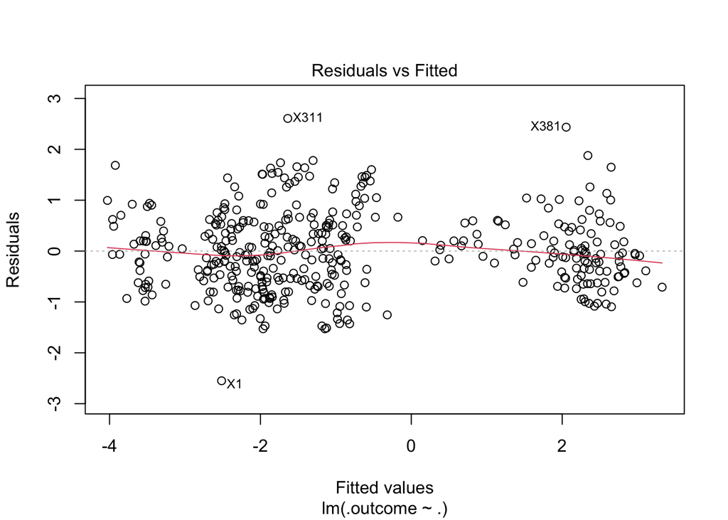

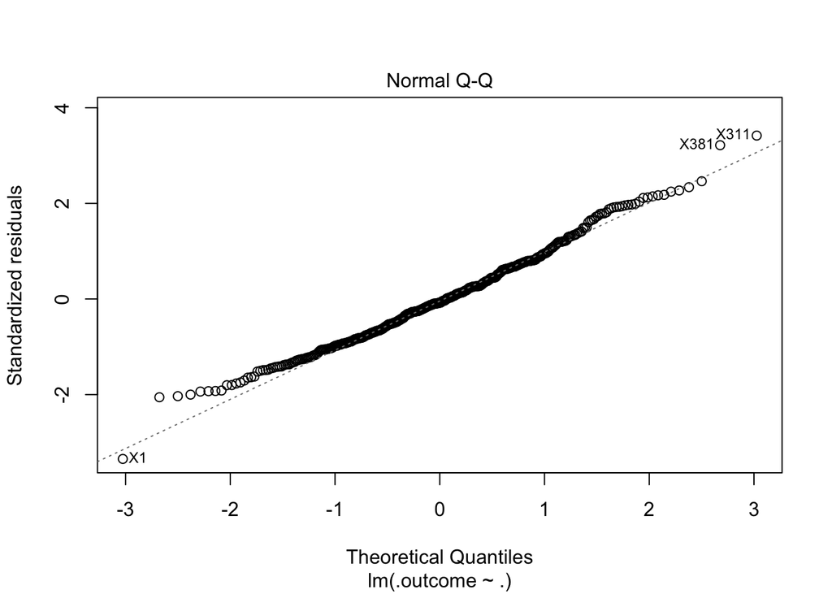

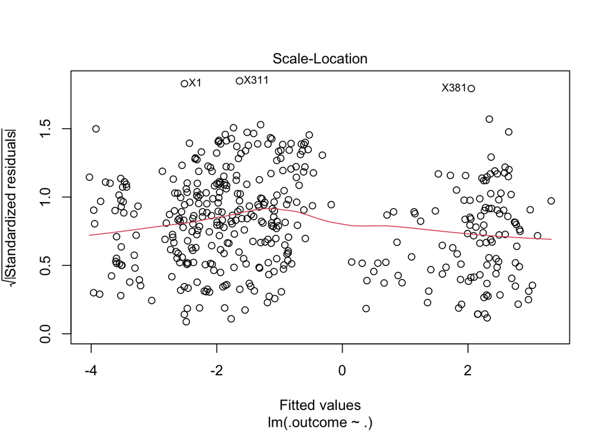

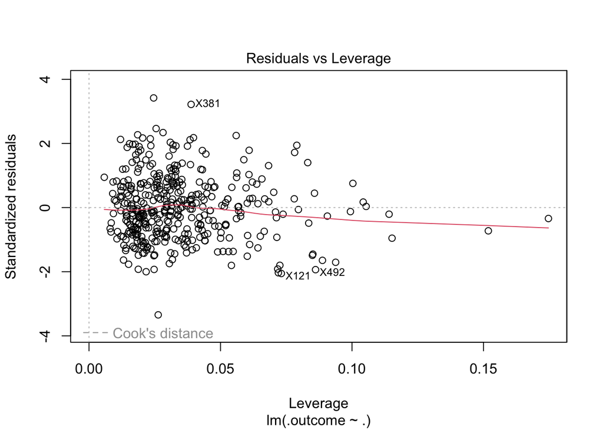

RMSE (Root Mean Squared Error) = 0.782

R^2 = 0.874, i.e. more than 87% of variability seen in response is because of the model.

Fitting alpha = 0, the best value of lambda = 1e-04 on full training set. For higher values of lambda, error increases.

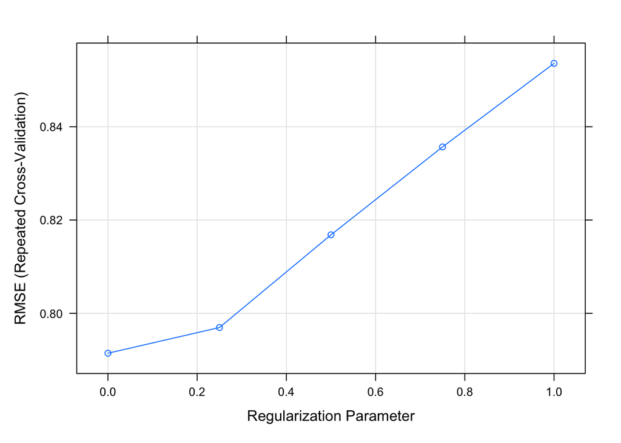

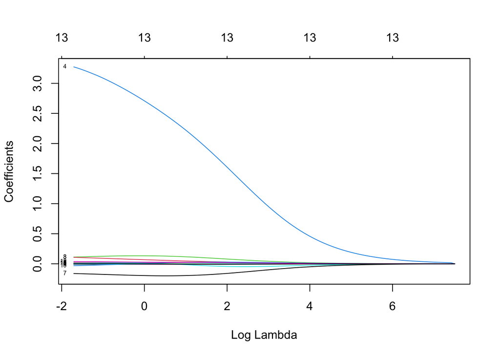

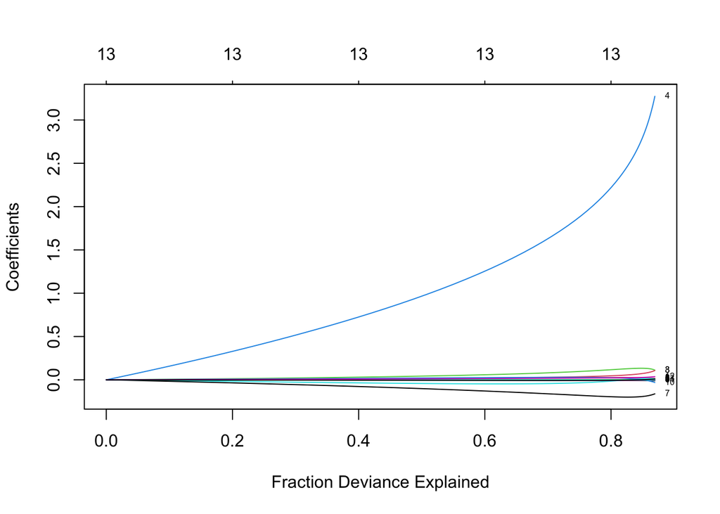

After fraction devience of 0.8, the coefficients become inflated and we start to see overfitting.

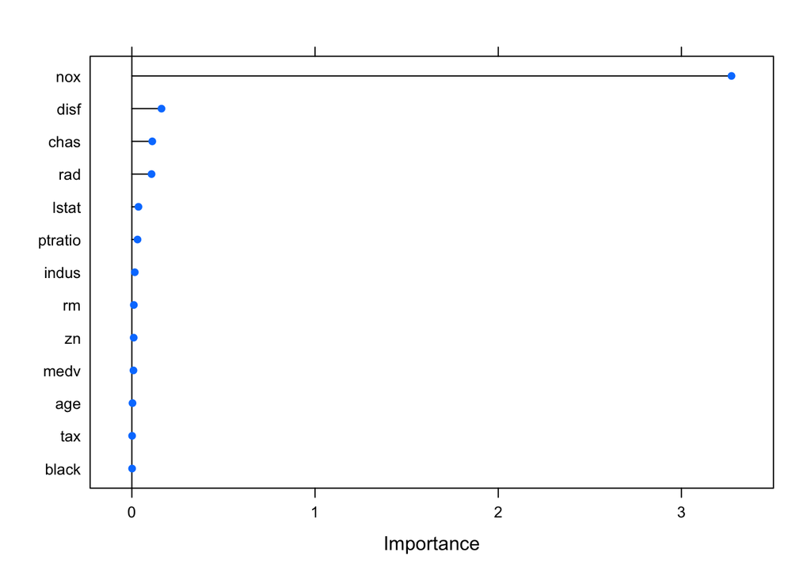

```r
#Variable Importance
plot(varImp(ridge, scale = F))
```

Plotting variable importance shows the NOX is the most improtant variable

### The LASSO

We will now use Lasso (least absolute shrinkage and selection operator) to build the regression model. This method shrinks regression coefficients, with some shrunk to zero. Thus, it helps with feature selection.

Fitting alpha = 1, the best valiue of lambda = 1e-04 on full training set, so we get a similar output to Ridge Regression.

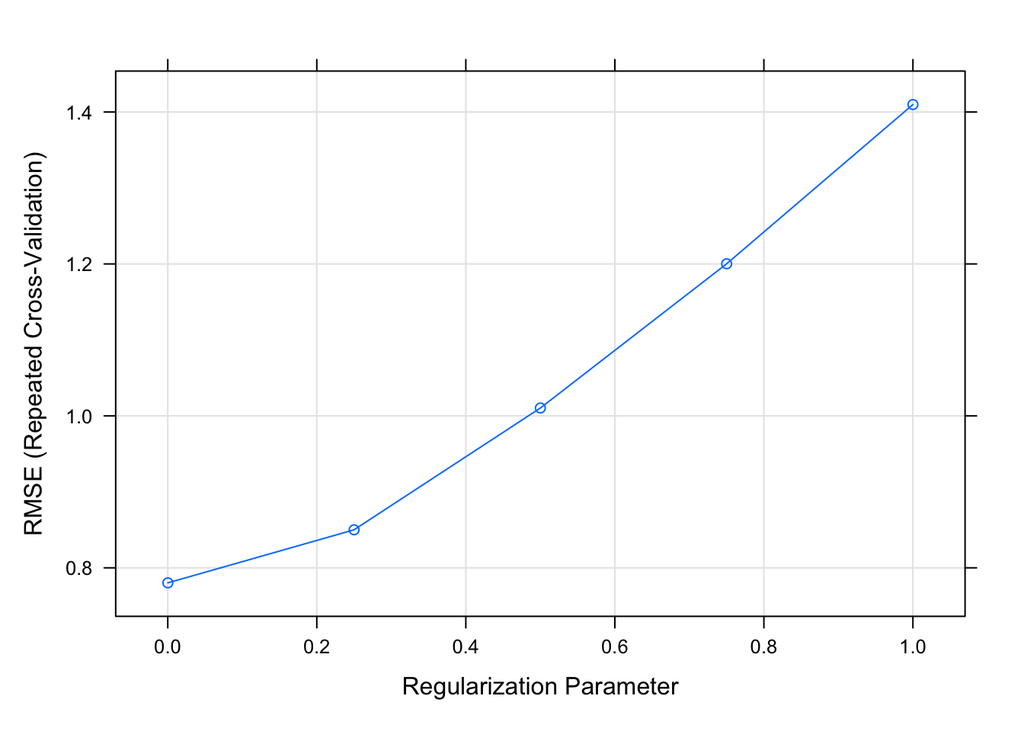

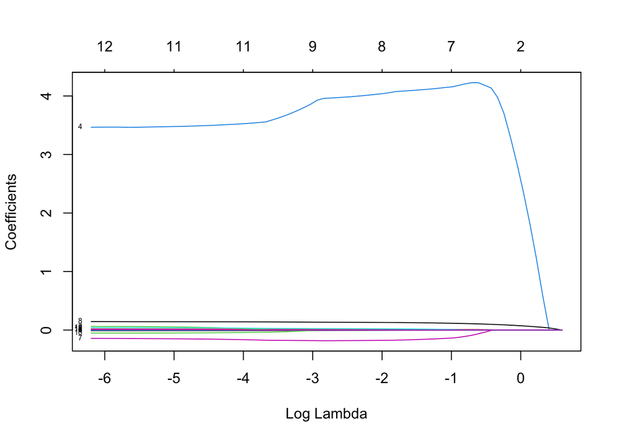

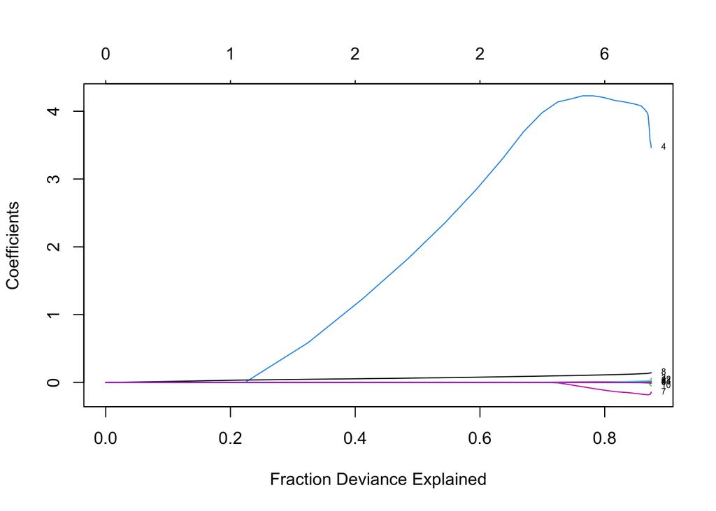

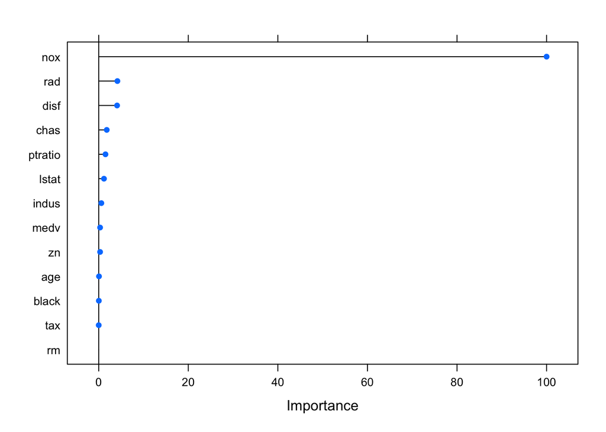

## Comparing Model Performances

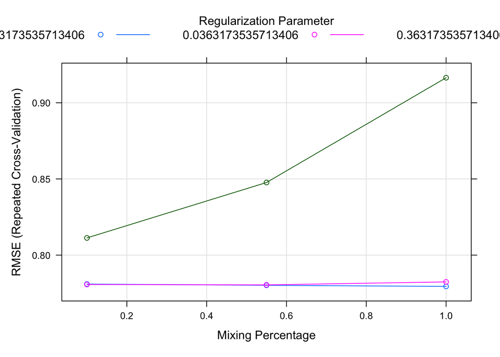

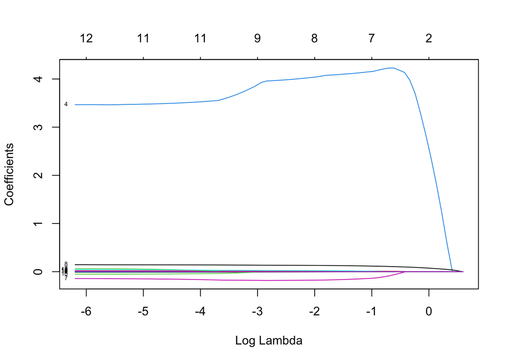

```r
#Plot Results
plot(en$finalModel, xvar = 'lambda', label=T)
```

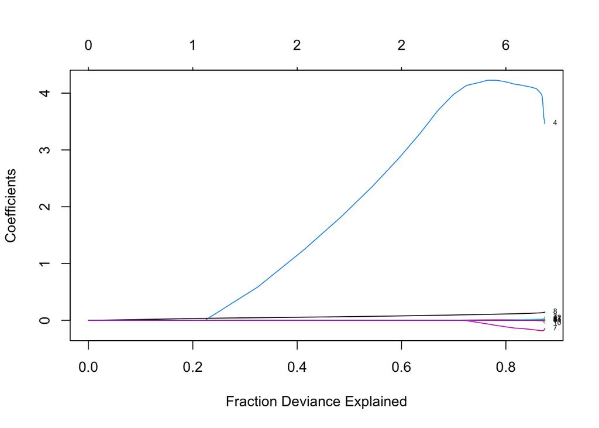

```r
plot(en$finalModel, xvar = 'dev', label=T)
```

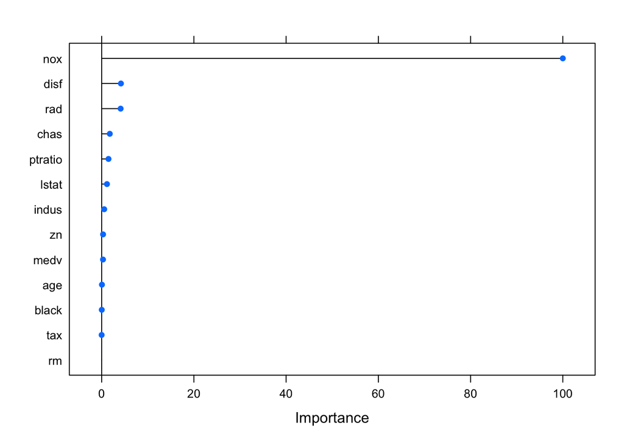

```r
plot(varImp(en))
```

```r
#Compare Models
model_list <- list(LinearModel = lm, Ridge = ridge, Lasso = lasso, ElasticNet = en)
res <- resamples(model_list)
summary(res)
```

```
##
## Call:
## summary.resamples(object = res)
##
## Models: LinearModel, Ridge, Lasso, ElasticNet
## Number of resamples: 50
##
## MAE
##                  Min.   1st Qu.    Median      Mean   3rd Qu.      Max. NA's
## LinearModel 0.3718703 0.5640444 0.6264179 0.6248028 0.6771217 0.8242991    0
## Ridge       0.3909361 0.5742287 0.6258109 0.6311926 0.6954140 0.7976763    0
## Lasso       0.3726157 0.5669105 0.6236312 0.6243478 0.6804045 0.8236866    0
## ElasticNet  0.3733750 0.5658067 0.6235520 0.6239583 0.6803930 0.8236739    0
##
## RMSE
##                  Min.   1st Qu.    Median      Mean   3rd Qu.      Max. NA's
## LinearModel 0.4879649 0.7161509 0.7869117 0.7813951 0.8491156 0.9912025    0
## Ridge       0.4918187 0.7306029 0.7814009 0.7914371 0.8595705 1.0110726    0
## Lasso       0.4879553 0.7181343 0.7859637 0.7802219 0.8458681 0.9910308    0
## ElasticNet  0.4881828 0.7181343 0.7846294 0.7794886 0.8458681 0.9912649    0
##
## Rsquared
##                  Min.   1st Qu.    Median      Mean   3rd Qu.      Max. NA's
## LinearModel 0.8018542 0.8510540 0.8742611 0.8711008 0.8891791 0.9472286    0
## Ridge       0.8081067 0.8459390 0.8679298 0.8679767 0.8878204 0.9487965    0
## Lasso       0.8015437 0.8518838 0.8733902 0.8714297 0.8890471 0.9474711    0
## ElasticNet  0.8012269 0.8524124 0.8733902 0.8716657 0.8890734 0.9475646    0
```

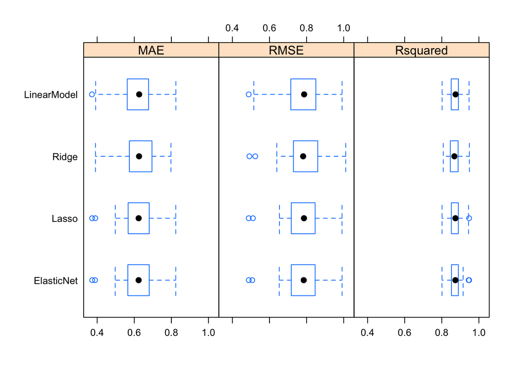

```r
bwplot(res)
```

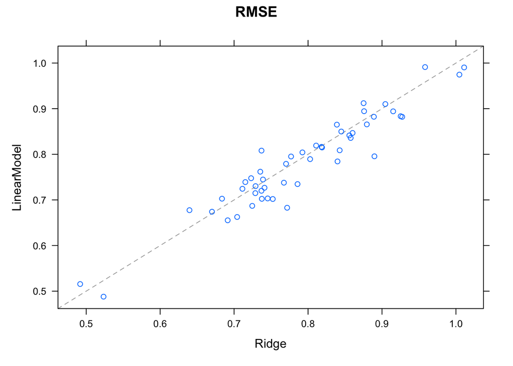

```r
xyplot(res, metric = 'RMSE')
```

```r
#Select best model
en$bestTune
```

```
##   alpha      lambda
## 7     1 0.003631735
```

```r
best <- en$finalModel
coef(best, s= en$bestTune$lambda)
```

```
## 14 x 1 sparse Matrix of class "dgCMatrix"
##                        s1
## (Intercept) -3.189625e+00
## zn          -1.072100e-02
## indus        1.928450e-02
## chas         6.118916e-02
## nox          3.463986e+00
## rm           .
## age         -2.295891e-03
## disf        -1.449207e-01
## rad          1.427123e-01
## tax         -1.101361e-05
## ptratio     -5.151634e-02
## black       -1.085291e-03
## lstat        3.998780e-02
## medv         1.024518e-02
```

```r
#Prediction
p1 <- predict(en, train)
sqrt(mean((train$lcrim)^2-p1))
```

```
## [1] 2.459693
```

```r
p2 <- predict(en, train)
sqrt(mean((test$lcrim)^2-p2))
```

```
## [1] 2.494686
```